# Блокнотная среда Jupyter Notebook

Jupyter Notebook предоставляет интерактивную среду для программирования на языке Python в веб-браузере. Главное преимущество этой среды по сравнению с обычной методикой использования консольной командной обо лочки IPython состоит в том, что код Python может объединяться с документацией (в том числе оформленной с помощью LaTeX), изображениями и даже с полноценными медиасредствами, такими как встроенные видеофрагменты. Виртуальные блокнотные среды Jupyter Notebook все больше используются научными работниками для обмена результатами их исследований, включающими процедуры вычисления, выполняемые с данными, так же просто, как результаты этих вычислений. Подобный формат упрощает совместную работу исследователей над проектом, а остальным предоставляет возможность тщательно проверить итоги исследований посредством воспроизведения вычислений с теми же данными.

## Основы использования Jupyter Notebook

### Запуск сервера Jupyter Notebook

Если блокнотная среда Jupyter Notebook уже установлена, то сервер, обеспечивающий браузерный интерфейс с командной оболочкой IPython, можно активизировать из командной строки:

```
jupyter notebook
```

После выполнения этой команды открывается окно веб-браузера с URL локального приложения Jupyter Notebook. По умолчанию это адрес http://localhost:8888, хотя по умолчанию можно определить другой номер порта, если 8888 уже используется.

[figure not shown]

Рис. 1. Начальная страница (index) блокнотной среды Jupyter Notebook

Начальная страница (index) блокнотной среды Jupyter Notebook (см. рис. 1) содержит список блокнотов, доступных в текущий момент в каталоге, из которого был запущен сервер.Это также каталог, в котором по умолчанию будут сохраняться блокноты (с расширением .ipynb). Поэтому правильным решением будет выполнение приведенной выше команды в каталоге проекта, с которым вы работаете.Начальная страница содержит три закладки: Files – список всех файлов, включая блокноты Jupyter Notebook и подкаталоги в текущем рабочем каталоге; Running – список блокнотов, в настоящий момент активных в текущем сеансе (даже если они не открыты в окне браузера); Clusters – предоставляет интерфейс к механизму параллельных вычислений IPython,но эта тема не рассматривается в данной книге.

На начальной странице можно создать новый блокнот (щелкнув по кнопке New > Notebook: Python 3) или открыть существующий (щелкнув по его имени). Для импорта существующего блокнота на начальную страницу можно либо щелкнуть по кнопке Upload (слева от кнопки New), либо перетащить в список блокнотов файл блокнота из любого приложения операционной системы, в котором указано имя этого файла. Чтобы остановить работу сервера блокнотов, нажмите клавиши Ctrl+C в окне терминала, из которого был запущен сервер (и подтвердите останов после вывода промпта).

## Редактирование блокнота Jupyter Notebook

Для начала работы с новым блокнотом щелкните по кнопке New и выберите ядро (должно предлагаться как минимум одно ядро с именем Python 3). Откроется новая вкладка браузера, содержащая интерфейс, где вы будете писать код и устанавливать соединение с ядром IPython, т. е. с процессом, отвечающим за выполнение кода и передачу полученных результатов обратно в браузер.

[figure not shown]

Рис. 2. Блокнотная среда Jupyter с новым документом-блокнотом

Новый документ-блокнот состоит из заголовка, панели меню и панели инструментов, под которыми расположен промпт командной оболочки IPython, где вы будете вводить код и команды разметки текста (например, описания и документацию) как последовательность ячеек (cells). В заголовке указано имя первого блокнота, открытого вами, – вероятнее всего, это будет имя Untitled (Без имени). Щелкните по имени, чтобы заменить его на более информативное название. Панель меню содержит команды сохранения, копирования, вывода (на печать и т. п.), реорганизации и прочих операций обработки документа Jupyter Notebook. На панели инструментов расположены значки на кнопках, предоставляющие более быстрые и удобные способы наиболее часто выполняемых операций, которые также доступны в панели меню.

Существует три типа ячеек ввода, в которых можно записывать содержимое блокнота:

- ячейки кода (code cells): тип ячейки по умолчанию. Этот тип ячеек состоит из выполняемого кода. При изучении данной главы вы будете писать в этих ячейках код Python, но Jupyter предоставляет механизм выполнения кода, написанного на других языках, таких как Julia и R;
- ячейки текста с разметкой (markdown cells): этот тип ячеек предоставляет богатые возможности оформления документации для исходного кода. При выполнении ввод в такую ячейку преобразуется в формат HTML, который может включать математические формулы, шрифтовое оформление, списки, таблицы, встроенные изображения и видеофрагменты;
- необработанные ячейки (raw cells): ввод в эти ячейки не изменяется блокнотной средой – полностью сохраняется содержимое и форматирование введенного текста.

## Работа с ячейками

Каждая ячейка может состоять из одной или нескольких строк ввода, но содержимое ячейки не интерпретируется до тех пор, пока вы не «запустите» (т. е. выполните) ее. Можно выбрать требуемый вариант в панели меню (в спускающемся подменю Cell), или щелкнуть по кнопке «воспроизведения» Run в панели инструментов, или воспользоваться одним из сочетаний «быстрых клавиш»:

- Shift+Enter – выполняет ячейку, выводит любой результат, затем перемещает курсор в ячейку, расположенную ниже. Если ниже нет ячейки, то создает новую пустую ячейку;
- Ctrl+Enter –выполняет текущую ячейку,но оставляет курсор в ней.Удобно для быстрой проверки правильности работы «одноразовых» команд или для извлечения списка содержимого каталога;
- Alt+Enter – выполняет ячейку, выводит любой результат, затем вставляет результат и перемещает курсор в новую ячейку, созданную прямо под текущей.

Существуют еще две полезные «быстрые клавиши». При редактировании ячейки клавиши со стрелками позволяют перемещаться по содержимому ячейки (режим редактирования). Если в этом режиме нажать клавишу Esc, то выполняется переход в режим команд, в котором клавиши со стрелками позволяют перемещаться между ячейками. Чтобы снова войти в режим редактирования выбранной ячейки, необходимо нажать клавишу Enter. В панели меню спускающееся подменю Cell предоставляет много способов выполнения ячеек блокнота: обычно требуется выполнение отдельной текущей ячейки или выполнение текущей ячейки и всех ячеек ниже нее.

## Ячейки кода

В ячейку кода можно вводить все, что допустимо при написании Pythonпрограммы в редакторе или в обычной командной оболочке IPython. Код в текущей ячейке имеет доступ к объектам, определенным в других ячейках (обеспечивая их совместную работу). Например:

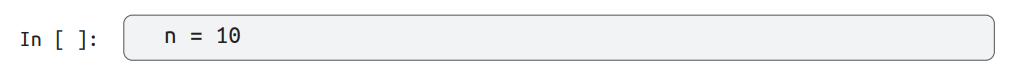

При нажатии клавиш Shift+Enter или при щелчке по кнопке Run выполняется эта инструкция (определение n, но без вывода) и открывается новая ячейка прямо под текущей:

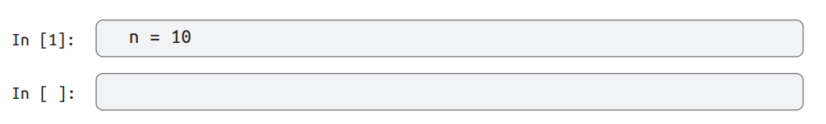

Ввод следующих инструкций в этой новой ячейке

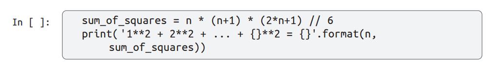

и их выполнение вышеописанным способом генерирует вывод и открывает третью пустую ячейку ввода. Теперь весь документ блокнота выглядит следующим образом:

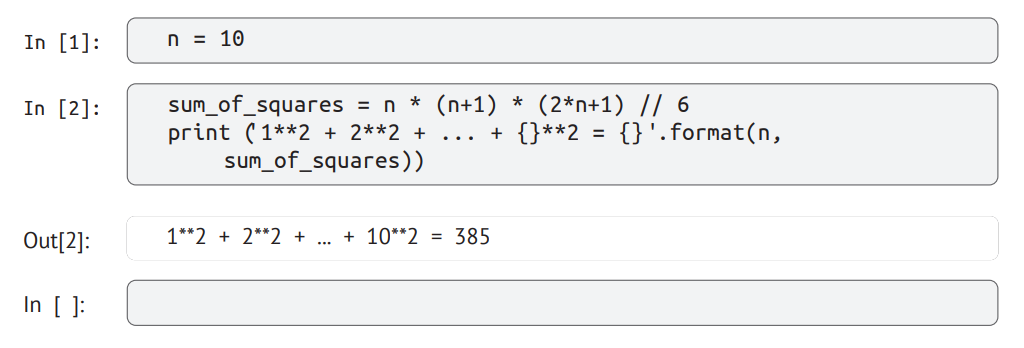

Можно отредактировать значение n в ячейке ввода 1 и повторно выполнить весь документ для обновления вывода. Следует отметить, что можно также установить новое значение для n после вычисления в ячейке 2:

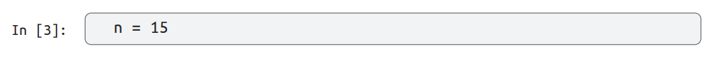

При выполнении ячейки 3, затем ячейки 2 вывод в ячейке 2 принимает следующий вид:

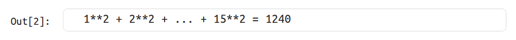

даже если в ячейке выше сохраняется определение значения 10 для переменной n. Таким образом, если вы не выполняете весь документ с самого начала, то вывод не обязательно отображает результат выполнения скрипта, соответствующий выполнению ячеек в порядке их расположения. В блокнотной среде Jupyter Notebook можно использовать все системные команды (с префиксами ! или !!) и магические функции IPython.